# C01

Next: Lecture 2 C Basics

Lecture 1 Introduction

#### CSCI218 Engineering Programming (by Kebin Xu)

1. Computer Hardware
2. Computer Software
3. Computer programming language
- Three generation of programming language
- Most popular programming language
- Intepreted vs compiled programming language
- Python vs C
- Why learn C in this class
1. Introduction to Arduino
- Arduino Hardware
  - Arduino board
  - micorcontroller and Arduino family
  - Types of memory of Arduino
  - Arduino Mega 2560
- Arduino Software
  - Understanding Arduino software architecture
  - Arduino IDE

1. Computer hardware

- A modern **computer** can be defined as “a machine that `stores and manipulates` information under the control of a `changeable program`.”
- **Hardware** are the physical devices that you can touch and see, such as a system unit, CPU, monitor, keyboard and mouse.
- **Software**, refers to a set of instructions which enable the hardware to perform a specific set of tasks.
- Software (programs) rule the hardware (the physical machine).

**1.1 Types of Hardware**

Hardware is grouped into 4 groups:

- **system unit** includes CPU (Central Processor Unit) and main memory (RAM)
- **secondary memory** (also called storage): eg. hard disk , CD, DVD
- information/data is passed to the computer through **Input devices** (keyboards, mice, etc.)
- processed information is presented to the user through **Output devices** ( monitor, printer) etc.

**1.2 CPU (Central Processing Unit)**

- CPU interpretes and carrries out the basic instructions that operate a computer
- It has a `control unit` that directs and coordinates most of the operations in the computer and an
- `arithmetic logic unit` (ALU): performs arithmetic(+, -, x, /), comparison (==, !==, >, <, >=, <=) , and other operations (logical AND, OR, NOT)

**1.3 Memory & storage**

**Memory** stores programs and data.

- main memory (**RAM** or Random Access Memory):
  - The CPU can only directly access information that is stored in main memory
  - is fast,
  - but volatile, i.e. when the power is interrupted, the contents of memory are lost.
- A **ROM**(Read only memory) chip is used primarily in the startup process of a computer (eg. BIOS check the peripherial), is not volatile (BIOS)
- Secondary memory(**storage device**) provides more permanent storage: magnetic (hard drive), flash (SSD, USB memory), optical (CD, DVD)

**1.4 Machine Cycle**

For every instruction, a processor repeats a set of `four` basic operations, which comprise a **machine cycle**

back to top

2. Computer Software

**softerware**: Software refers to a set of instructions which enable the hardware to perform a specific set of tasks.

**2.1 Main types of software**

- **System software** (operating system, driver software)
- **Application software**(MS Office Suite, web browser, DBMS, etc. )
- **Programming Software** for different programming launguage: C, C++, Java, Python, C#, Go ..

**2.2 Natural language vs programs**

**Natural language** has ambiguity and imprecision problems when used to describe complex algorithms

**Programs** expressed in an unambiguous, precise way using programming languages.

- Every structure in programming language has a precise form, called its **syntax**
- Every structure in programming language has a precise meaning, called its **semantics**.

**Computer program**:

- A detailed, step-by-step set of `instructions` telling a computer what to do.
- Programs are `executed`, or carried out.
- The process of creating this software is called **programming**

Remember that a program is just a sequence of instructions telling a computer what to do. Obviously, we need to provide those instructions in a `language` that a computer can understand.

back to top

3. Programming language

There are three generation of programming language

**3.1 Three generation of programming language**

### Machine language

A computer circuit represents the 0 or the 1 electronically by the presence or absence of an electrical charge. All the data and instructions are represented are binary (0 or 1 ).

The language/instructions a computer can understand/execute is **machine launguage** in the form of binary, for example : 001000 01100 10000 0000000000000101 tell computer to add 5 and the number in the register t4 and save the result to register S0. (addi $s0, $t4, 5 )

Instructions/code writen in machine language is hard for people to remember and modify, so comes **Assembly language**, then **high-level programming languages** (e.g. C, Python, Java, etc.).

### Assembly language (LLL) and High-Level Language(HLL)

**Assembly Language** is also called low-level language(LLL)

**High Level Language** (HLL) You may have heard of some other languages, such as Python, C, C++, Java, Perl. Although these languages differ in many details, they all share the property of having well-defined, unambiguous syntax and semantics. Languages themselves tend to evolve over time!

back to top

**3.2 Most popular programming languages**

```c
from IPython.display import YouTubeVideo
YouTubeVideo('Og847HVwRSI', width=800, height=400)
```

[video not shown]

back to top

**3.3 intepreted vs compiled programming language**

the programs/softwares written in the high-leval programming language need to be **compiled/intepreted** to machine launguage.

back to top

**3.4 Python vs C**

### Example programs written by Python and C

```c
# Python: correct
name = "James"
print("Hello", name)
a = 13
print(a)
b = 5
print("a + b = ", a + b)
```

```
Hello James
13
a + b =  18
```

```c
# Python: code with error
name = "James"
print("Hello", name)

print(a)
b = 5
print("a + b = ", a + b)
```

```
Hello James
```

```
---------------------------------------------------------------------------
NameError                                 Traceback (most recent call last)
/var/folders/rf/39bvqq590xxg9k9mtzxztx3n1rd5gf/T/ipykernel_48910/3198745244.py in <module>
      3 print("Hello", name)
      4
----> 5 print(a)
      6 b = 5
      7 print("a + b = ", a + b)

NameError: name 'a' is not defined
```

```c
// C : correct
#include <stdio.h>

int main()
{
 char name[] = "James";
 printf("Hello, %s\n", name);
 int a = 13;
 printf("%d\n",a);
 int b = 5;
 printf("a + b = %d\n", a + b);
 return 0;
}
```

```
Hello, James
13
a + b = 18
```

```c
// C :  code with error
#include <stdio.h>

int main()
{
 char name[] = "James";
 printf("Hello, %s\n", name);
 int a = 13
 printf("%d\n",a);
 int b = 5;
 printf("a + b = %d\n", a + b);
 return 0;
}
```

```
/var/folders/z9/vkhgx2kd5cq0lkb6xnntgssr0000gq/T/tmpwaqagpz8.c:8:12: error: expected ';' at end of declaration
 int a = 13
           ^
           ;
1 error generated.
[C kernel] GCC exited with code 1, the executable will not be executed
```

Back to top

**3.5 Why C?**

back to top

4. Introduction to Arduino

- Arduino is a simple **microcontroller board** which is normally used in engineering projects where there's a need to automate something.
  - For example, you can interface sensors with this board, can drive motors with this board, can plug switches in it etc.
  - With Arduino, you can build objects that can respond to and/or control light, sound, touch, and movement.
  - It can be used to blink a Morse-code signal using a single light-emitting diode (LED)
- check this fun video [Intro to Arduino](https://www.youtube.com/watch?v=CqrQmQqpHXc)
- Arduino is made up of both `hardware` and `software`.
- We can say that Arduino is a single-board computer(An entire microcomputer on a single printed circuit board. Examples include the Arduino™ and the Raspberry Pi.). Arduino is an open-source electronics platform based on easy-to-use hardware and software. It's intended for anyone making interactive projects.

4.1 Arduino Hardware

**4.1.1 Arduino board**

- The **Arduino board** is a printed circuit board (PCB) designed to use a `microcontroller chip` as well as other input and outputs

In 2005, the Arduino team designed a [microcontroller](https://www.elprocus.com/difference-between-avr-arm-8051-and-pic-microcontroller/) board and released it under an open-source license. Over the years, the Arduino team improved the board’s design and released several new versions. They usually had Italian names, such as Uno, Duemilanove, or Diecimila; you can find online a list of all boards ever created by the Arduino team.see [Arduino products](http://arduino.cc/en/Main/Products) and [Arduino old boards](http://arduino.cc/en/Main/Boards)

- Here’s a small selection of Arduinos. They may differ in their appearance, but they have a lot in common, and you can program them all with the same tools and libraries.

[figure not shown]

Although they’re the same in principle, they differ in some details.

back to top

**4.1.2 micorcontroller and Arduino family**

- A **microcontroller** chip is a small computer contained in a single, `integrated circuit(IC)` ( or called computer chip)
  - The microcontroller is the brains of a system, but it needs other electronic inputs and outputs to either sense or affect things in its environment.

### [micorcontroller vs genearl purpose microprocessor](https://www.elprocus.com/microprocessor-and-microcontroller/)

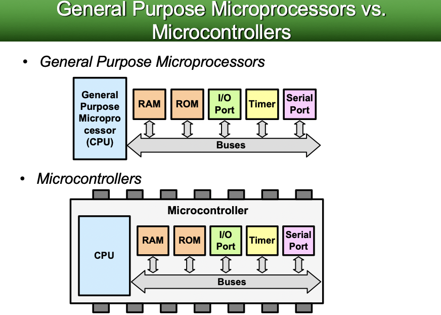

In the above:

- The processor/CPU is the brain, the part where all decisions are taken and which can calculate.
- Memories are often both spaces where both the core inner-self program and the user elements are running
  - Read Only Memory (ROM). A ROM chip is used primarily in the startup process of a computer
  - Random Access Memory (RAM). CPU can only directly access information stored in RAM, and it is fast, but volatile, i.e. when the power is interrupted, the contents of memory are lost.
- **Inputs**: inputs are senses for your Arduino. They tell it what is going on in the world. At its most basic, an input could be a switch, such as a light switch in your home
- **Outputs**: outputs allow your Arduino to affect the real world in some way. An output could be subtle and discrete, such as in the vibration of a cellphone, or it could be a huge visual display on the side of a building that can be seen for miles around. The first sketch in the book walks you through blinking an LED (see Lesson 3). From there, you can go on to controlling an electric motor (Lesson 7) and even controlling an LCD screen (Lesson 12).

## Arduino microcontroller

#### Arduino Mega 2560 Pin Mapping

- The microcontroller socket connects all the legs of the ATmega2560 microcontroller chip to other sockets, referred to as header sockets, which are arranged around the edge of the board and are labeled for ease of use. These black sockets are divided into four main groups: **digital pins**, **analog input pins**, **power pins** and **communication pins**.
- All these pins transfer a voltage （e.g. 5v), which can be either sent as output or received as an input. Arduino is special because it can interpret these electric signals and convert them to digital signals (0s and 1s) that your computer can understand — and vice versa.
- ICSP stands for In-Circuit Serial Programming, These pins enable the user to program the Arduino boards' firmware

## Atmel Microcontrollers family

The Arduino™ family of Single-Board Computers (SBCs)

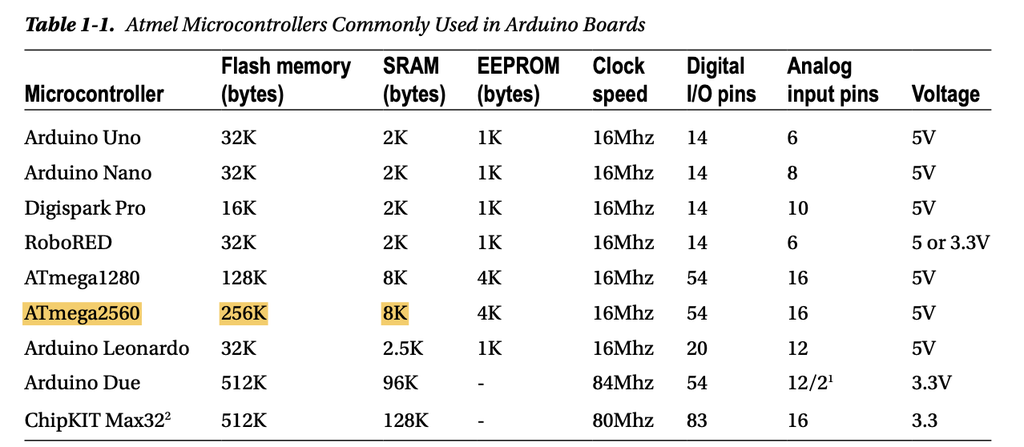

back to top

**4.1.3 Types of Memory of Arduino**

**RAM, ROM, and Flash Memory**

- **RAM**: Stands for random access memory; refers to memory that the microprocessor can read from and write to. When you create something in memory, it’s done in RAM. It is temporary and `volatile`.
- **ROM**: Stands for read-only memory. The microprocessor can read from ROM, but it can’t write to it or modify it. ROM is permanent (not erasable). Often, ROM chips contain special instructions for the computer — important stuff that never changes. The microprocessor can access information stored on a ROM chip whenever it needs to.
- **Flash memory**:
  - In Arduino, flash memeory is a special type of memory that works like both RAM and ROM. You can write information to flash memory, like you can with RAM, but that information isn’t erased when the power is off, like it is with ROM.
  - When you have the program code/skeche written in your PC and upload that program code from your PC to the microcontroller (μc in short) board via the USB connection. The program code is stored in the Arduino’s flash memory.
  - Flash memory is `nonvolatile`
  - 2K to 8K of flash memory is used for the software (i.e., the `bootloader`) that allows your program to communicate with the outside world, including your PC. Bootloaders are the first programs to inhabit an MCU when you power them up. Bootloaders instruct the MCU what to load or do next.
  - most sets have 100,000 writes.
- **SRAM** (static random-access memory), is where your program variables (data) get stored during program execution. It creating temporary variables as the program executes. Is volatile.
- **EEPROM**(Electrically Erasable Programmable Read-Only Memory ) is an area of nonvolatile memory where one often stores data that needs to be retrievable each time the program is run. it is a little slower to access than flash memory. EEPROM memory is often used to store configuration or other types of information that are needed when the system powers up

[figure not shown]

back to top

**4.1.4 Arduino Mega 2560**

The Arduino Mega 2560 is a [8-bit](https://resources.altium.com/p/8-bit-vs-32-bit-mcu-choosing-right-microcontroller-your-pcb-design) microcontroller board based on the [ATmega2560](http://ww1.microchip.com/downloads/en/DeviceDoc/Atmel-2549-8-bit-AVR-Microcontroller-ATmega640-1280-1281-2560-2561_datasheet.pdf). It has **54** digital input/output pins (of which 15 can be used as PWM outputs), **16** analog inputs, 4 UARTs(universal asynchronous receiver-transmitter devices ) (hardware serial ports), a 16 MHz crystal oscillator, a USB connection, a power jack, an [ICSP](https://www.microcontrollertips.com/programming-avr-microcontrollers-arduinos-arduino-isp/) header, and a reset button. It contains everything needed to support the microcontroller; simply connect it to a computer with a USB cable or power it with a AC-to-DC adapter or battery to get started. The Mega 2560 board is compatible with most shields designed for the Uno and the former boards Duemilanove or Diecimila.

[figure not shown]

#### USB socket

you send programs primarily by a USB connection. The Arduino uses the USB both for power and to transfer data. Using a USB cable is perfect for low-power applications and when data is being sent to or received from a computer.

#### Power socket

It allows you to power your Arduino from an external power supply. The supply could be from an AC-to-DC adaptor (similar to those used on other consumer electronics), a battery, or even a solar panel.

#### Digital pins (54 I/O)

You use digital pins(54 pins) to send and receive digital signals. Digital implies that the pins have two states: off or on. In electrical terms, these states translate to a value of 0 or 5 volts, but no values in between. These pins receive two values HIGH and LOW. When they receive 5V the pins are at HIGH state while when they receive 0V the pins remain in a LOW state.

#### Analog in pins (16)

You use analog in pins(16 pins)(from A0 to A15) to receive an analog value. An analog value is taken from a range of values. In this case, the range is the same 0V to 5V as with the digital pins, but the value can be at any point — 0.1, 0.2, 0.3, and so on.

#### Analog out pins

you can writes an analog value (PWM wave) to a pin. Can be used to light a LED at varying brightnesses or drive a motor at various speeds. Analog out pins are hidden among the digital pins marked as [[PWM]](https://www.theengineeringprojects.com/2018/10/introduction-to-pwm-pulse-width-modulation.html)(pulse-width modulation), which is a technique you can use to give the impression of an analog output using digital pins.

#### Power pins

You use the power pins to distribute power to inputs and outputs wherever power is needed.

- `Vin`, which stands for voltage in, can be used to supply a voltage (V) equal to the one supplied by the external supply jack (for example, 12V). You can also use this pin to supply power to the Arduino from another source.
- `GND` marks the ground pins, which are essential to complete circuits.
- You can use 5V or 3.3V to supply a 5-volt or 3.3-volt power supply, respectively, to components or circuits.

#### LEDs

An LED is a component that produces light when electrical current flows through it. (LEDs come in a variety of shapes and sizes and are found in almost every modern piece of consumer electronics, from bike lights to TVs to washing machines. )

- The board has four LEDs (light-emitting diodes) labeled L, RX, TX, and ON. These four LEDs are used to indicate activity on the board, as follows:
  - » ON is green and signifies that your Arduino is powered.
  - » RX and TX tell you that data is being received or transmitted by the board.
  - » L is a special LED connected to digital pin 13. It is great for testing to see whether your board is functioning as you want.
- If your Arduino is plugged in but you don’t see any lights, double-check that:
  - » Your USB cable is plugged in -> » Your USB port is working — try another device in the port

If the LED still doesn’t illuminate, check the [troubleshooting](https://www.dummies.com/computers/arduino/arduino-projects-for-dummies-cheat-sheet/) or you need replace Arduino board

#### Reset button

It resets the program on the Arduino or stops it completely when held down for a time. Connecting a wire between GND and the reset pin, which is located next to the 3.3V, achieves the same results.

back to top

4.2 Arduino Software

**4.2.1 Understanding Arduino software architecture**

In order to understand how to make our nice Arduino board work exactly as we want it to, we have to understand the global software architecture Let's have a look at a small diagram for better understanding:

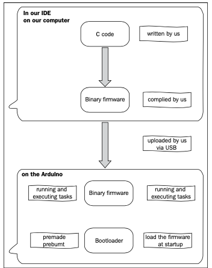

**4.2.2 Arduino IDE**

Software programs, called `sketches`, are created on a computer using the [Arduino integrated development environment (IDE)](https://www.arduino.cc/en/software) . The `IDE` enables you to write and edit code and convert this code into instructions that Arduino hardware understands. The IDE also transfers those instructions to the Arduino board (a process called uploading) Details see lab1.pdf

back to top